# Time series of Environmental Sensors: basic analysis

## 4. Smoothing

### 4.1. Removing seasonal effects by smoothing

Seasonal-Trend Decomposition with LOESS

We now turn our attention to time series that show both trend and seasonal effect. The goal is to specify a filtering approach that allows trend estimation for periodic data.

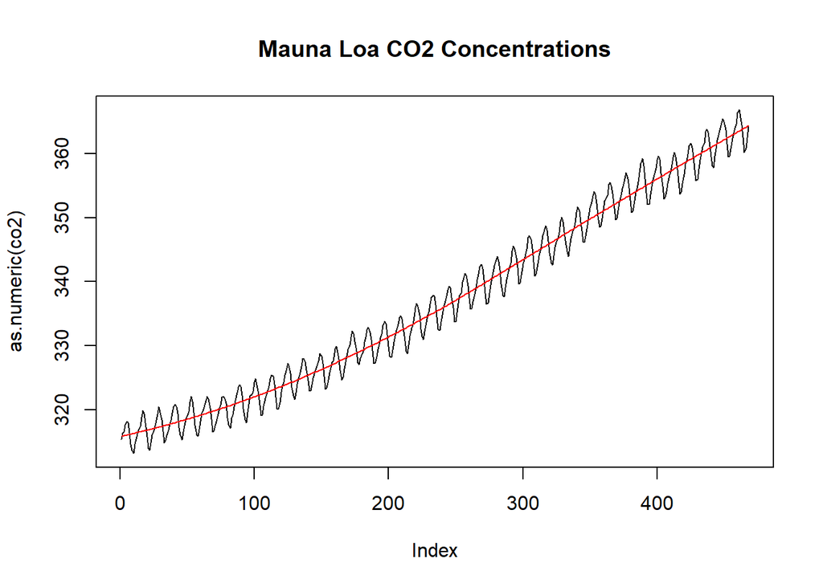

```r
fit <- loess(co2~time(co2))
trend.est <- predict(fit)
plot(as.numeric(co2), type="l",main="Mauna Loa CO2 Concentrations")
lines(trend.est, col="red")
```

## 5. Autocorrelation

An important feature of time series is their (potential) serial correlation. The Autocorrelation function (ACF) measures the correlation between observations at different distances apart. Or, in other words, defines how data points in a time series are related, on average, to the preceding data points (or the self-similarity of the signal over different delay times).

### 5.1. Lagged Scatterplot

An appealing idea for analyzing the correlation among consecutive observations in the above series is to produce a scatterplot of (x1,xt+1) for all t=1,….,n-1. There is a designated function `lag.plot()` in R. The result is as follows:

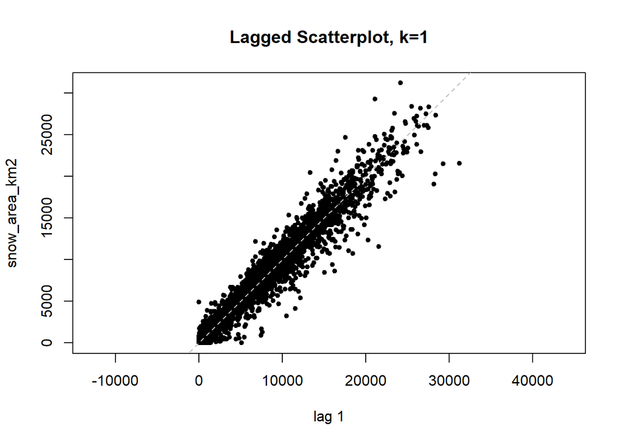

```r
lag.plot(snow.ts, do.lines=FALSE, pch=20)
title("Lagged Scatterplot, k=1")
```

### 5.2. Correlogram

Now we will estimate the autocorrelation function (ACF) for any lag k . Here, we introduce the correlogram, the standard means of visualization for the ACF. We will then also study the properties of the ACF estimator. We employ R and obtain:

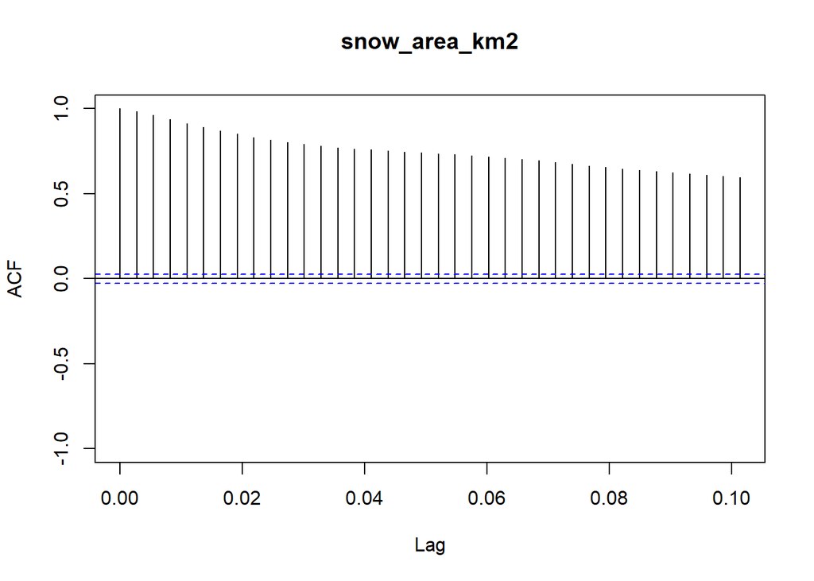

```r
acf(snow.ts, ylim=c(-1,1))
```

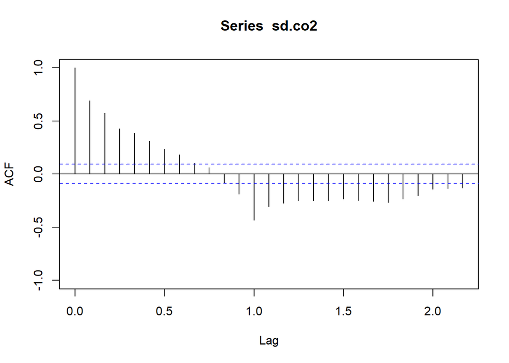

```r
acf(sd.co2, ylim=c(-1,1))
```

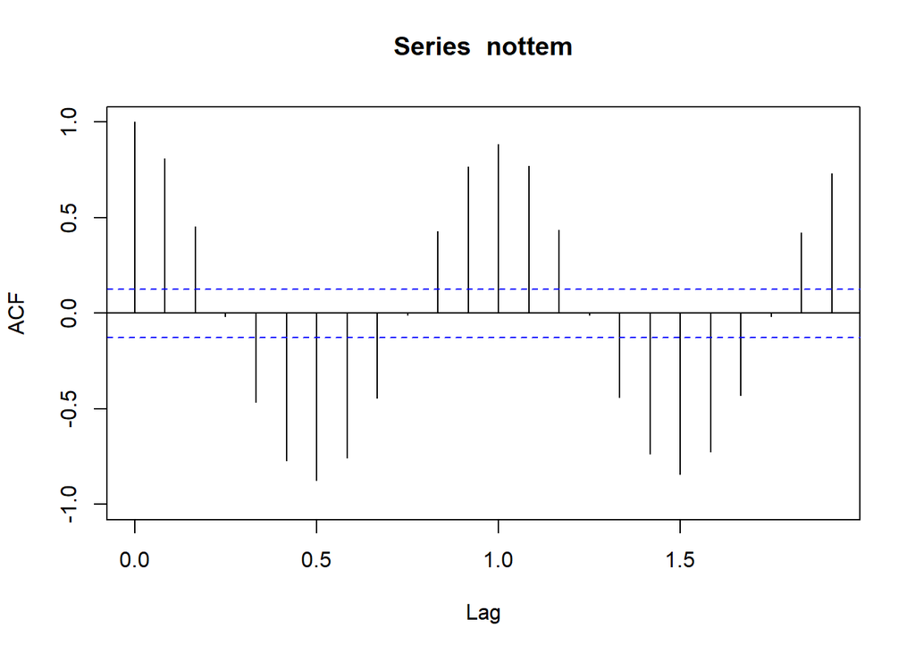

```r
data(nottem)
acf(nottem, ylim=c(-1,1))
```

#B. Advanced analysis tools

## 1. Change points and structural breaks

- Kotzé, K. *Tutorial: Change points and structural breaks* [Website](https://kevin-kotze.gitlab.io/tsm/ts-2-tut/).

## 2. Spectral analysis

### 2.1. Wavelet analysis

Cazellas, B. et al., 2008 *Wavelet analysis of ecological time series* [Website](https://link.springer.com/article/10.1007/s00442-008-0993-2).

Rosch, A. 2018 *WaveletComp 1.1: A guided tour through the R package* [Website](http://www.hs-stat.com/projects/WaveletComp/WaveletComp_guided_tour.pdf)

### 2.2. Wavelet coherence analysis

Gouhier, T. et al., 2021 *Package ‘biwavelet’* [Website](https://cran.r-project.org/web/packages/biwavelet/biwavelet.pdf)

## 3. Stationary time series models

- Dettling, M. *Time Series Analysis: ETH Course* [Website](https://www.dropbox.com/s/m4ryp8qcchoukg4/Time%20Series%20Analysis_ETH_COURSE.pdf?dl=0).

## 4. Time series regression

- Dettling, M. *Time Series Analysis: ETH Course* [Website](https://www.dropbox.com/s/m4ryp8qcchoukg4/Time%20Series%20Analysis_ETH_COURSE.pdf?dl=0).

## 5. Time series forecasting

- Dettling, M. *Time Series Analysis: ETH Course* [Website](https://www.dropbox.com/s/m4ryp8qcchoukg4/Time%20Series%20Analysis_ETH_COURSE.pdf?dl=0).

## 6. Multivariate time series analysis

- Dettling, M. *Time Series Analysis: ETH Course* [Website](https://www.dropbox.com/s/m4ryp8qcchoukg4/Time%20Series%20Analysis_ETH_COURSE.pdf?dl=0).

## 7. State space models

- Dettling, M. *Time Series Analysis: ETH Course* [Website](https://www.dropbox.com/s/m4ryp8qcchoukg4/Time%20Series%20Analysis_ETH_COURSE.pdf?dl=0).
[^1]: CREAF, gomez.gener87@gmail.com